# Is it Really More Fun in the Philippines?: An Exploratory Data Analysis on the State of the Philippines in World Happiness Reports

Raphael E. Gutierrez • March 12, 2022

The World Happiness Report is a publication of the Sustainable Development Solutions Network that publishes annual reports of national happiness based on the ratings of each criteria. These criteria are the natural log GDP per capita, social support, healthy life expectancy at birth, freedom to make life choices, generosity, and perceptions of corruption. The main feature of the dataset is the happiness score, also referred to as Cantril life ladder, or ladder score. Respondents are asked to think of a ladder, with the best possible life for them being a 10, and the worst possible life being a 0. The report correlates the life evaluation results with other features mentioned earlier.

This analysis seeks to answer the following questions:

1. What is the state of the happiness score of the Philippines in the world?
2. What are the factors that highly affect the happiness score of the Philippines?
3. Does GDP per capita influence the happiness score of the Philippines? How strong is the correlation between two features?

The datasets used in this analysis are retrieved from https://worldhappiness.report/ed/2021/.

# Preliminaries

This section imports all the necessary packages for the analysis and sets the style of the plots.

```python
import numpy as np
import pandas as pd
import matplotlib.pyplot as plt
import seaborn as sns
from scipy.stats import pearsonr

#%matplotlib notebook
%matplotlib inline

plt.style.use("ggplot")

params = {'font.family': ['Arial', 'Helvetica'],
          'text.color': "#222",
          'axes.labelcolor': "#222",
          'xtick.color': "#222",
          'ytick.color': "#222"}

plt.rcParams.update(params)
```

# Data Preparation

This section imports and prepares the datasets to be used in the analysis.

```python
# Importing 2005-2020 dataset

file_all = pd.ExcelFile("Downloads/DataPanelWHR2021C2.xls")
df_all_raw = pd.read_excel(file_all)
```

```python
df_all_raw.head()
```

|  | Country name | year | Life Ladder | Log GDP per capita | Social support | Healthy life expectancy at birth | Freedom to make life choices | Generosity | Perceptions of corruption | Positive affect | Negative affect |
| --- | --- | --- | --- | --- | --- | --- | --- | --- | --- | --- | --- |
| 0 | Afghanistan | 2008 | 3.723590 | 7.370100 | 0.450662 | 50.799999 | 0.718114 | 0.167640 | 0.881686 | 0.517637 | 0.258195 |
| 1 | Afghanistan | 2009 | 4.401778 | 7.539972 | 0.552308 | 51.200001 | 0.678896 | 0.190099 | 0.850035 | 0.583926 | 0.237092 |
| 2 | Afghanistan | 2010 | 4.758381 | 7.646709 | 0.539075 | 51.599998 | 0.600127 | 0.120590 | 0.706766 | 0.618265 | 0.275324 |
| 3 | Afghanistan | 2011 | 3.831719 | 7.619532 | 0.521104 | 51.919998 | 0.495901 | 0.162427 | 0.731109 | 0.611387 | 0.267175 |
| 4 | Afghanistan | 2012 | 3.782938 | 7.705479 | 0.520637 | 52.240002 | 0.530935 | 0.236032 | 0.775620 | 0.710385 | 0.267919 |

```python
# Importing 2021 dataset

file_2021 = pd.ExcelFile("Downloads/DataForFigure2.1WHR2021C2.xls")
df_2021_raw = pd.read_excel(file_2021)
```

```python
df_2021_raw.head()
```

|  | Country name | Regional indicator | Ladder score | Standard error of ladder score | upperwhisker | lowerwhisker | Logged GDP per capita | Social support | Healthy life expectancy | Freedom to make life choices | Generosity | Perceptions of corruption | Ladder score in Dystopia | Explained by: Log GDP per capita | Explained by: Social support | Explained by: Healthy life expectancy | Explained by: Freedom to make life choices | Explained by: Generosity | Explained by: Perceptions of corruption | Dystopia + residual |
| --- | --- | --- | --- | --- | --- | --- | --- | --- | --- | --- | --- | --- | --- | --- | --- | --- | --- | --- | --- | --- |
| 0 | Finland | Western Europe | 7.8421 | 0.031646 | 7.904126 | 7.780075 | 10.775202 | 0.953603 | 72.000000 | 0.949268 | -0.097760 | 0.185846 | 2.430343 | 1.446356 | 1.106192 | 0.740824 | 0.690577 | 0.124200 | 0.480524 | 3.253415 |
| 1 | Denmark | Western Europe | 7.6195 | 0.034657 | 7.687428 | 7.551572 | 10.933176 | 0.954410 | 72.699753 | 0.945639 | 0.030109 | 0.178838 | 2.430343 | 1.501548 | 1.108008 | 0.762862 | 0.686160 | 0.207615 | 0.484993 | 2.868296 |
| 2 | Switzerland | Western Europe | 7.5715 | 0.036243 | 7.642536 | 7.500463 | 11.117368 | 0.941742 | 74.400101 | 0.918788 | 0.024629 | 0.291698 | 2.430343 | 1.565899 | 1.079469 | 0.816415 | 0.653488 | 0.204040 | 0.413019 | 2.839148 |
| 3 | Iceland | Western Europe | 7.5539 | 0.059373 | 7.670271 | 7.437528 | 10.877768 | 0.982938 | 73.000000 | 0.955123 | 0.160274 | 0.672865 | 2.430343 | 1.482190 | 1.172279 | 0.772319 | 0.697701 | 0.292526 | 0.169940 | 2.966945 |
| 4 | Netherlands | Western Europe | 7.4640 | 0.027326 | 7.517559 | 7.410441 | 10.931812 | 0.941601 | 72.400116 | 0.913116 | 0.175404 | 0.337938 | 2.430343 | 1.501072 | 1.079151 | 0.753425 | 0.646585 | 0.302397 | 0.383531 | 2.797818 |

# Descriptive Statistics

Descriptive statistics are used to describe or summarize the characteristics of each dataset. The summary includes the central tendency, dispersion, count, shape, and other statistical methods.

### 2005-2020 Dataset

```python
df_all_raw.shape
```

```
(1949, 11)
```

```python
df_all_raw.describe()
```

|  | year | Life Ladder | Log GDP per capita | Social support | Healthy life expectancy at birth | Freedom to make life choices | Generosity | Perceptions of corruption | Positive affect | Negative affect |
| --- | --- | --- | --- | --- | --- | --- | --- | --- | --- | --- |
| count | 1949.000000 | 1949.000000 | 1913.000000 | 1936.000000 | 1894.000000 | 1917.000000 | 1860.000000 | 1839.000000 | 1927.000000 | 1933.000000 |
| mean | 2013.216008 | 5.466707 | 9.368459 | 0.812553 | 63.359375 | 0.742567 | 0.000108 | 0.747111 | 0.709998 | 0.268552 |
| std | 4.166828 | 1.115717 | 1.154091 | 0.118480 | 7.510244 | 0.142104 | 0.162221 | 0.186793 | 0.107106 | 0.085176 |
| min | 2005.000000 | 2.375092 | 6.635322 | 0.290184 | 32.299999 | 0.257534 | -0.335040 | 0.035198 | 0.321690 | 0.082737 |
| 25% | 2010.000000 | 4.640079 | 8.463744 | 0.749390 | 58.685000 | 0.647048 | -0.112973 | 0.690305 | 0.625373 | 0.206403 |
| 50% | 2013.000000 | 5.386025 | 9.460323 | 0.835167 | 65.199997 | 0.763476 | -0.025393 | 0.802428 | 0.722391 | 0.258117 |
| 75% | 2017.000000 | 6.283498 | 10.352778 | 0.905291 | 68.589998 | 0.856030 | 0.090967 | 0.871942 | 0.799276 | 0.319716 |
| max | 2020.000000 | 8.018934 | 11.648169 | 0.987343 | 77.099998 | 0.985178 | 0.698099 | 0.983276 | 0.943621 | 0.704590 |

### 2021 Dataset

```python
df_2021_raw.shape
```

```
(149, 20)
```

```python
df_2021_raw.describe()
```

|  | Ladder score | Standard error of ladder score | upperwhisker | lowerwhisker | Logged GDP per capita | Social support | Healthy life expectancy | Freedom to make life choices | Generosity | Perceptions of corruption | Ladder score in Dystopia | Explained by: Log GDP per capita | Explained by: Social support | Explained by: Healthy life expectancy | Explained by: Freedom to make life choices | Explained by: Generosity | Explained by: Perceptions of corruption | Dystopia + residual |
| --- | --- | --- | --- | --- | --- | --- | --- | --- | --- | --- | --- | --- | --- | --- | --- | --- | --- | --- |
| count | 149.000000 | 149.000000 | 149.000000 | 149.000000 | 149.000000 | 149.000000 | 149.000000 | 149.000000 | 149.000000 | 149.000000 | 149.000000 | 149.000000 | 149.000000 | 149.000000 | 149.000000 | 149.000000 | 149.000000 | 149.000000 |
| mean | 5.532832 | 0.058764 | 5.648008 | 5.417655 | 9.432209 | 0.814726 | 64.992784 | 0.791572 | -0.015149 | 0.727477 | 2.430343 | 0.977153 | 0.793315 | 0.520132 | 0.498687 | 0.178091 | 0.135112 | 2.430343 |
| std | 1.073923 | 0.022011 | 1.054320 | 1.094875 | 1.158585 | 0.114892 | 6.762071 | 0.113315 | 0.150653 | 0.179266 | 0.000000 | 0.404777 | 0.258840 | 0.212971 | 0.137885 | 0.098277 | 0.114322 | 0.537653 |
| min | 2.522900 | 0.025583 | 2.596468 | 2.449332 | 6.635322 | 0.462596 | 48.478001 | 0.381749 | -0.288153 | 0.081959 | 2.430343 | 0.000000 | 0.000000 | 0.000000 | 0.000000 | 0.000000 | 0.000000 | 0.648460 |
| 25% | 4.851800 | 0.043369 | 4.991074 | 4.705666 | 8.540956 | 0.749777 | 59.801552 | 0.718051 | -0.126469 | 0.666607 | 2.430343 | 0.665774 | 0.646990 | 0.356634 | 0.409224 | 0.105473 | 0.060408 | 2.138343 |
| 50% | 5.533500 | 0.054181 | 5.624688 | 5.413106 | 9.568728 | 0.831914 | 66.603096 | 0.804414 | -0.036025 | 0.780623 | 2.430343 | 1.024849 | 0.832038 | 0.570849 | 0.514314 | 0.164473 | 0.101220 | 2.509446 |
| 75% | 6.255400 | 0.069863 | 6.344270 | 6.127992 | 10.421198 | 0.904702 | 69.599998 | 0.877263 | 0.078830 | 0.844619 | 2.430343 | 1.322677 | 0.996021 | 0.665236 | 0.602958 | 0.239398 | 0.173931 | 2.793570 |
| max | 7.842100 | 0.172664 | 7.904126 | 7.780075 | 11.646564 | 0.982938 | 76.952858 | 0.970131 | 0.541553 | 0.939343 | 2.430343 | 1.750786 | 1.172279 | 0.896814 | 0.715964 | 0.541250 | 0.546775 | 3.482495 |

# Data Pre-processing

This section pre-processes the datasets: analyze null values, impute values to null fields using forward fill, select features to be used for the analysis, and concatenate the two datasets.

### 2005-2020 Dataset

```python
# Prints concise summary of the dataset

df_all_raw.info()
```

```
<class 'pandas.core.frame.DataFrame'>
RangeIndex: 1949 entries, 0 to 1948
Data columns (total 11 columns):
 #   Column                            Non-Null Count  Dtype
---  ------                            --------------  -----
 0   Country name                      1949 non-null   object
 1   year                              1949 non-null   int64
 2   Life Ladder                       1949 non-null   float64
 3   Log GDP per capita                1913 non-null   float64
 4   Social support                    1936 non-null   float64
 5   Healthy life expectancy at birth  1894 non-null   float64
 6   Freedom to make life choices      1917 non-null   float64
 7   Generosity                        1860 non-null   float64
 8   Perceptions of corruption         1839 non-null   float64
 9   Positive affect                   1927 non-null   float64
 10  Negative affect                   1933 non-null   float64
dtypes: float64(9), int64(1), object(1)
memory usage: 167.6+ KB
```

```python
# Checking null values per column

df_all_raw.isna().sum()
```

```
Country name                          0
year                                  0
Life Ladder                           0
Log GDP per capita                   36
Social support                       13
Healthy life expectancy at birth     55
Freedom to make life choices         32
Generosity                           89
Perceptions of corruption           110
Positive affect                      22
Negative affect                      16
dtype: int64
```

```python
# Percentage of null values

df_all_raw.isna().mean() * 100
```

```
Country name                        0.000000
year                                0.000000
Life Ladder                         0.000000
Log GDP per capita                  1.847101
Social support                      0.667009
Healthy life expectancy at birth    2.821960
Freedom to make life choices        1.641868
Generosity                          4.566444
Perceptions of corruption           5.643920
Positive affect                     1.128784
Negative affect                     0.820934
dtype: float64
```

```python
df_null = pd.DataFrame({"column": df_all_raw.columns,
                        "% null": df_all_raw.isna().mean() * 100,
                        "% notnull": 100 - df_all_raw.isna().mean() * 100})

df_null
```

|  | column | % null | % notnull |
| --- | --- | --- | --- |
| Country name | Country name | 0.000000 | 100.000000 |
| year | year | 0.000000 | 100.000000 |
| Life Ladder | Life Ladder | 0.000000 | 100.000000 |
| Log GDP per capita | Log GDP per capita | 1.847101 | 98.152899 |
| Social support | Social support | 0.667009 | 99.332991 |
| Healthy life expectancy at birth | Healthy life expectancy at birth | 2.821960 | 97.178040 |
| Freedom to make life choices | Freedom to make life choices | 1.641868 | 98.358132 |
| Generosity | Generosity | 4.566444 | 95.433556 |
| Perceptions of corruption | Perceptions of corruption | 5.643920 | 94.356080 |
| Positive affect | Positive affect | 1.128784 | 98.871216 |
| Negative affect | Negative affect | 0.820934 | 99.179066 |

```python
df_null_sum = pd.DataFrame({"type": ["% notnull", "% null"],
                        "count": [df_null["% notnull"].mean(), df_null["% null"].mean()]})

df_null_sum
```

|  | type | count |
| --- | --- | --- |
| 0 | % notnull | 98.26018 |
| 1 | % null | 1.73982 |

```
<BarContainer object of 2 artists>
```

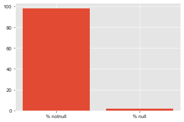

```python
# Plotting percentage of null and notnull values

plt.bar(x=df_null_sum["type"], height=df_null_sum["count"])
```

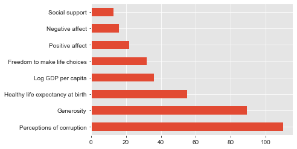

```python
# Plotting columns with null values

sorted_df_all_raw_na = df_all_raw.isna().sum().sort_values(ascending=False)

sorted_df_all_raw_na[sorted_df_all_raw_na != 0].plot(kind="barh")
```

### Imputing Values

```python
df_all_imputed = df_all_raw.fillna(method="ffill")

df_all_imputed.isna().sum()
```

```
Country name                        0
year                                0
Life Ladder                         0
Log GDP per capita                  0
Social support                      0
Healthy life expectancy at birth    0
Freedom to make life choices        0
Generosity                          0
Perceptions of corruption           0
Positive affect                     0
Negative affect                     0
dtype: int64
```

### 2021 Dataset

```python
# Prints concise summary of the dataset

df_2021_raw.info()
```

```
<class 'pandas.core.frame.DataFrame'>
RangeIndex: 149 entries, 0 to 148
Data columns (total 20 columns):
 #   Column                                      Non-Null Count  Dtype
---  ------                                      --------------  -----
 0   Country name                                149 non-null    object
 1   Regional indicator                          149 non-null    object
 2   Ladder score                                149 non-null    float64
 3   Standard error of ladder score              149 non-null    float64
 4   upperwhisker                                149 non-null    float64
 5   lowerwhisker                                149 non-null    float64
 6   Logged GDP per capita                       149 non-null    float64
 7   Social support                              149 non-null    float64
 8   Healthy life expectancy                     149 non-null    float64
 9   Freedom to make life choices                149 non-null    float64
 10  Generosity                                  149 non-null    float64
 11  Perceptions of corruption                   149 non-null    float64
 12  Ladder score in Dystopia                    149 non-null    float64
 13  Explained by: Log GDP per capita            149 non-null    float64
 14  Explained by: Social support                149 non-null    float64
 15  Explained by: Healthy life expectancy       149 non-null    float64
 16  Explained by: Freedom to make life choices  149 non-null    float64
 17  Explained by: Generosity                    149 non-null    float64
 18  Explained by: Perceptions of corruption     149 non-null    float64
 19  Dystopia + residual                         149 non-null    float64
dtypes: float64(18), object(2)
memory usage: 23.4+ KB
```

```python
# Checking null values per column

df_2021_raw.isna().sum()
```

```
Country name                                  0
Regional indicator                            0
Ladder score                                  0
Standard error of ladder score                0
upperwhisker                                  0
lowerwhisker                                  0
Logged GDP per capita                         0
Social support                                0
Healthy life expectancy                       0
Freedom to make life choices                  0
Generosity                                    0
Perceptions of corruption                     0
Ladder score in Dystopia                      0
Explained by: Log GDP per capita              0
Explained by: Social support                  0
Explained by: Healthy life expectancy         0
Explained by: Freedom to make life choices    0
Explained by: Generosity                      0
Explained by: Perceptions of corruption       0
Dystopia + residual                           0
dtype: int64
```

### Feature Selection, Renaming, and Joining Datasets

```python
# Selecting features that will be used for EDA

df1_raw = df_all_imputed[["Country name", "year", "Life Ladder", "Log GDP per capita", "Social support", "Healthy life expectancy at birth",
            "Freedom to make life choices", "Generosity", "Perceptions of corruption"]]

df2_raw = df_2021_raw[["Country name", "Ladder score", "Logged GDP per capita", "Social support", "Healthy life expectancy",
            "Freedom to make life choices", "Generosity", "Perceptions of corruption"]]
```

```python
df1 = df1_raw.rename(columns={"Country name": "Country", "Healthy life expectancy at birth": "Healthy life expectancy",
                          "Life Ladder": "Ladder score"})

df2 = df2_raw.rename(columns={"Country name": "Country", "Logged GDP per capita": "Log GDP per capita"})
```

```python
# Concatenating (union) two datasets

df = pd.concat([df1, df2], ignore_index=True)
```

```python
df.shape
```

```
(2098, 9)
```

```python
df.describe()
```

|  | year | Ladder score | Log GDP per capita | Social support | Healthy life expectancy | Freedom to make life choices | Generosity | Perceptions of corruption |
| --- | --- | --- | --- | --- | --- | --- | --- | --- |
| count | 1949.000000 | 2098.000000 | 2098.000000 | 2098.000000 | 2098.000000 | 2098.000000 | 2098.000000 | 2098.000000 |
| mean | 2013.216008 | 5.471403 | 9.378010 | 0.813161 | 63.439433 | 0.746260 | -0.001448 | 0.740181 |
| std | 4.166828 | 1.112682 | 1.153046 | 0.118080 | 7.451472 | 0.141071 | 0.160730 | 0.188215 |
| min | 2005.000000 | 2.375092 | 6.635322 | 0.290184 | 32.299999 | 0.257534 | -0.335040 | 0.035198 |
| 25% | 2010.000000 | 4.652504 | 8.480264 | 0.750301 | 58.804999 | 0.651839 | -0.114605 | 0.681997 |
| 50% | 2013.000000 | 5.391887 | 9.464589 | 0.835835 | 65.199997 | 0.768215 | -0.028290 | 0.797906 |
| 75% | 2017.000000 | 6.282982 | 10.371108 | 0.905294 | 68.615086 | 0.859330 | 0.089273 | 0.866382 |
| max | 2020.000000 | 8.018934 | 11.648169 | 0.987343 | 77.099998 | 0.985178 | 0.698099 | 0.983276 |

### Imputing Year 2021

```python
# All 149 null years will be imputed with value "2021"

df.isna().sum()
```

```
Country                           0
year                            149
Ladder score                      0
Log GDP per capita                0
Social support                    0
Healthy life expectancy           0
Freedom to make life choices      0
Generosity                        0
Perceptions of corruption         0
dtype: int64
```

```python
df["year"].fillna(2021, inplace=True)

df["year"].value_counts()
```

```
2021.0    149
2017.0    147
2011.0    146
2014.0    145
2019.0    144
2015.0    143
2016.0    142
2018.0    142
2012.0    142
2013.0    137
2010.0    124
2009.0    114
2008.0    110
2007.0    102
2020.0     95
2006.0     89
2005.0     27
Name: year, dtype: int64
```

```python
# Converting float year to int

df = df.astype({"year": "int32"})

np.dtype(df["year"])
```

```
dtype('int32')
```

```python
df.describe()
```

|  | year | Ladder score | Log GDP per capita | Social support | Healthy life expectancy | Freedom to make life choices | Generosity | Perceptions of corruption |
| --- | --- | --- | --- | --- | --- | --- | --- | --- |
| count | 2098.000000 | 2098.000000 | 2098.000000 | 2098.000000 | 2098.000000 | 2098.000000 | 2098.000000 | 2098.000000 |
| mean | 2013.768827 | 5.471403 | 9.378010 | 0.813161 | 63.439433 | 0.746260 | -0.001448 | 0.740181 |
| std | 4.486449 | 1.112682 | 1.153046 | 0.118080 | 7.451472 | 0.141071 | 0.160730 | 0.188215 |
| min | 2005.000000 | 2.375092 | 6.635322 | 0.290184 | 32.299999 | 0.257534 | -0.335040 | 0.035198 |
| 25% | 2010.000000 | 4.652504 | 8.480264 | 0.750301 | 58.804999 | 0.651839 | -0.114605 | 0.681997 |
| 50% | 2014.000000 | 5.391887 | 9.464589 | 0.835835 | 65.199997 | 0.768215 | -0.028290 | 0.797906 |
| 75% | 2018.000000 | 6.282982 | 10.371108 | 0.905294 | 68.615086 | 0.859330 | 0.089273 | 0.866382 |
| max | 2021.000000 | 8.018934 | 11.648169 | 0.987343 | 77.099998 | 0.985178 | 0.698099 | 0.983276 |

### Creating dataframe grouped by countries sorted by Ladder score

```python
df_groupby_country = df.groupby(["Country"], as_index=False).mean()

df_groupby_country_sorted = df_groupby_country.sort_values(by="Ladder score", ascending=False, ignore_index=True)

df_groupby_country_sorted
```

|  | Country | year | Ladder score | Log GDP per capita | Social support | Healthy life expectancy | Freedom to make life choices | Generosity | Perceptions of corruption |
| --- | --- | --- | --- | --- | --- | --- | --- | --- | --- |
| 0 | Denmark | 2013.437500 | 7.676504 | 10.882655 | 0.957034 | 71.264984 | 0.945163 | 0.143516 | 0.199057 |
| 1 | Finland | 2014.285714 | 7.614708 | 10.751747 | 0.949302 | 71.238572 | 0.940386 | -0.004024 | 0.244426 |
| 2 | Switzerland | 2015.181818 | 7.550344 | 11.097398 | 0.943440 | 73.430918 | 0.924320 | 0.099061 | 0.304636 |
| 3 | Norway | 2015.090909 | 7.501651 | 11.040443 | 0.950735 | 72.727273 | 0.954847 | 0.132170 | 0.337352 |
| 4 | Netherlands | 2013.733333 | 7.466140 | 10.889793 | 0.934058 | 71.753341 | 0.907887 | 0.262452 | 0.409758 |
| ... | ... | ... | ... | ... | ... | ... | ... | ... | ... |
| 161 | Togo | 2014.500000 | 3.610234 | 7.251579 | 0.467384 | 53.045435 | 0.622966 | -0.024408 | 0.800060 |
| 162 | Burundi | 2013.500000 | 3.585987 | 6.707979 | 0.429764 | 51.330001 | 0.480237 | -0.034526 | 0.711381 |
| 163 | Central African Republic | 2012.200000 | 3.514954 | 6.960998 | 0.402559 | 43.356001 | 0.680430 | 0.026931 | 0.842129 |
| 164 | Afghanistan | 2014.076923 | 3.512188 | 7.654218 | 0.504734 | 52.284047 | 0.507530 | 0.056831 | 0.849518 |
| 165 | South Sudan | 2015.500000 | 3.401875 | 10.648074 | 0.554719 | 50.410000 | 0.493705 | -0.105868 | 0.749433 |

166 rows × 9 columns

# Helper Functions

### Function for single plot with two features

```python
def plot_line(x, y, title, subtitle, x_label, y_label, title_x):
    plt.figure(figsize=(14,8))
    plt.plot(x, y, marker="o")
    plt.ylim(4.5, 7)

    # plt.legend(fontsize=14)
    plt.locator_params(axis="y", nbins=10)
    plt.suptitle(title, x=title_x, y=0.95, fontsize=20, fontweight="bold")
    plt.title(subtitle, loc="left", fontsize=14)

    plt.xticks(fontsize=14); plt.yticks(fontsize=14)
    plt.xlabel(x_label, fontsize=14); plt.ylabel(y_label, fontsize=14)
    # plt.gca().xaxis.grid(False)
    plt.show()
```

### Function for scatter plot of two features with year as data points

```python
def plot_scatter(x, y, marker, title, subtitle, x_label, y_label, title_x, point_x):
    plt.figure(figsize=(14,8))

    plt.scatter(x, y, s=80)

    # plt.legend(fontsize=14)
    plt.locator_params(axis="y", nbins=12)
    plt.suptitle(title, x=title_x, y=0.95, fontsize=20, fontweight="bold")
    plt.title(subtitle, loc="left", fontsize=14)

    plt.xticks(fontsize=14); plt.yticks(fontsize=14)
    plt.xlabel(x_label, fontsize=14); plt.ylabel(y_label, fontsize=14)
    # plt.gca().xaxis.grid(False)

    for x_axis, y_axis, mark in zip (x, y, marker):
        plt.text(x_axis+point_x, y_axis, mark, fontsize=12)

    plt.show()
```

# Philippines Historical Data (2006-2021)

```python
# Creating df of Philippines

df_ph = df[df["Country"] == "Philippines"]

df_ph
```

|  | Country | year | Ladder score | Log GDP per capita | Social support | Healthy life expectancy | Freedom to make life choices | Generosity | Perceptions of corruption |
| --- | --- | --- | --- | --- | --- | --- | --- | --- | --- |
| 1380 | Philippines | 2006 | 4.669946 | 8.561845 | 0.795313 | 59.799999 | 0.828273 | 0.063402 | 0.841299 |
| 1381 | Philippines | 2007 | 5.073562 | 8.607889 | 0.800711 | 60.000000 | 0.851566 | -0.021588 | 0.880246 |
| 1382 | Philippines | 2008 | 4.589065 | 8.633818 | 0.798442 | 60.200001 | 0.860843 | 0.082775 | 0.816585 |
| 1383 | Philippines | 2009 | 4.879911 | 8.631698 | 0.775171 | 60.400002 | 0.873605 | 0.003718 | 0.804578 |
| 1384 | Philippines | 2010 | 4.941514 | 8.685817 | 0.804861 | 60.599998 | 0.893351 | 0.033068 | 0.812448 |
| 1385 | Philippines | 2011 | 4.993957 | 8.706756 | 0.788763 | 60.799999 | 0.882837 | 0.072544 | 0.782946 |
| 1386 | Philippines | 2012 | 5.001965 | 8.756410 | 0.812922 | 61.000000 | 0.914500 | 0.052633 | 0.771168 |
| 1387 | Philippines | 2013 | 4.976925 | 8.804813 | 0.846413 | 61.200001 | 0.907458 | 0.021115 | 0.756389 |
| 1388 | Philippines | 2014 | 5.312550 | 8.849893 | 0.813300 | 61.400002 | 0.902186 | -0.015336 | 0.787219 |
| 1389 | Philippines | 2015 | 5.547489 | 8.895648 | 0.853589 | 61.599998 | 0.911534 | -0.051160 | 0.755192 |
| 1390 | Philippines | 2016 | 5.430833 | 8.949631 | 0.821299 | 61.700001 | 0.907596 | -0.071243 | 0.791962 |
| 1391 | Philippines | 2017 | 5.594270 | 9.002189 | 0.851029 | 61.799999 | 0.925703 | -0.141393 | 0.711166 |
| 1392 | Philippines | 2018 | 5.869173 | 9.049713 | 0.845803 | 61.900002 | 0.917808 | -0.107958 | 0.726483 |
| 1393 | Philippines | 2019 | 6.267745 | 9.094725 | 0.845095 | 62.000000 | 0.909599 | -0.082581 | 0.748442 |
| 1394 | Philippines | 2020 | 5.079585 | 9.061443 | 0.781140 | 62.099998 | 0.932042 | -0.115543 | 0.744284 |
| 2009 | Philippines | 2021 | 5.880200 | 9.075588 | 0.829926 | 61.999954 | 0.916999 | -0.096836 | 0.741764 |

```python
# Descriptive statistics of Philippines data from 2006-2021

df_ph.describe()
```

|  | year | Ladder score | Log GDP per capita | Social support | Healthy life expectancy | Freedom to make life choices | Generosity | Perceptions of corruption |
| --- | --- | --- | --- | --- | --- | --- | --- | --- |
| count | 16.000000 | 16.000000 | 16.000000 | 16.000000 | 16.000000 | 16.000000 | 16.000000 | 16.000000 |
| mean | 2013.500000 | 5.256793 | 8.835492 | 0.816486 | 61.156247 | 0.895994 | -0.023399 | 0.779511 |
| std | 4.760952 | 0.470919 | 0.186457 | 0.026144 | 0.772843 | 0.029039 | 0.073614 | 0.044414 |
| min | 2006.000000 | 4.589065 | 8.561845 | 0.775171 | 59.799999 | 0.828273 | -0.141393 | 0.711166 |
| 25% | 2009.750000 | 4.968073 | 8.672817 | 0.797660 | 60.549999 | 0.880529 | -0.086144 | 0.747403 |
| 50% | 2013.500000 | 5.076574 | 8.827353 | 0.813111 | 61.300001 | 0.907527 | -0.018462 | 0.777057 |
| 75% | 2017.250000 | 5.559184 | 9.014070 | 0.845272 | 61.825000 | 0.915124 | 0.037959 | 0.806546 |
| max | 2021.000000 | 6.267745 | 9.094725 | 0.853589 | 62.099998 | 0.932042 | 0.082775 | 0.880246 |

```python
df_groupby_country_sorted
```

|  | Country | year | Ladder score | Log GDP per capita | Social support | Healthy life expectancy | Freedom to make life choices | Generosity | Perceptions of corruption |
| --- | --- | --- | --- | --- | --- | --- | --- | --- | --- |
| 0 | Denmark | 2013.437500 | 7.676504 | 10.882655 | 0.957034 | 71.264984 | 0.945163 | 0.143516 | 0.199057 |
| 1 | Finland | 2014.285714 | 7.614708 | 10.751747 | 0.949302 | 71.238572 | 0.940386 | -0.004024 | 0.244426 |
| 2 | Switzerland | 2015.181818 | 7.550344 | 11.097398 | 0.943440 | 73.430918 | 0.924320 | 0.099061 | 0.304636 |
| 3 | Norway | 2015.090909 | 7.501651 | 11.040443 | 0.950735 | 72.727273 | 0.954847 | 0.132170 | 0.337352 |
| 4 | Netherlands | 2013.733333 | 7.466140 | 10.889793 | 0.934058 | 71.753341 | 0.907887 | 0.262452 | 0.409758 |
| ... | ... | ... | ... | ... | ... | ... | ... | ... | ... |
| 161 | Togo | 2014.500000 | 3.610234 | 7.251579 | 0.467384 | 53.045435 | 0.622966 | -0.024408 | 0.800060 |
| 162 | Burundi | 2013.500000 | 3.585987 | 6.707979 | 0.429764 | 51.330001 | 0.480237 | -0.034526 | 0.711381 |
| 163 | Central African Republic | 2012.200000 | 3.514954 | 6.960998 | 0.402559 | 43.356001 | 0.680430 | 0.026931 | 0.842129 |
| 164 | Afghanistan | 2014.076923 | 3.512188 | 7.654218 | 0.504734 | 52.284047 | 0.507530 | 0.056831 | 0.849518 |
| 165 | South Sudan | 2015.500000 | 3.401875 | 10.648074 | 0.554719 | 50.410000 | 0.493705 | -0.105868 | 0.749433 |

166 rows × 9 columns

```python
df_groupby_country_sorted[df_groupby_country_sorted["Country"] == "Philippines"]
```

|  | Country | year | Ladder score | Log GDP per capita | Social support | Healthy life expectancy | Freedom to make life choices | Generosity | Perceptions of corruption |
| --- | --- | --- | --- | --- | --- | --- | --- | --- | --- |
| 85 | Philippines | 2013.5 | 5.256793 | 8.835492 | 0.816486 | 61.156247 | 0.895994 | -0.023399 | 0.779511 |

### Sorting ladder score by log GDP per capita

```python
# Sort Philippines data by Ladder score

df_ph[["year", "Ladder score", "Log GDP per capita"]].sort_values(by="Ladder score", ascending=False)
```

|  | year | Ladder score | Log GDP per capita |
| --- | --- | --- | --- |
| 1393 | 2019 | 6.267745 | 9.094725 |
| 2009 | 2021 | 5.880200 | 9.075588 |
| 1392 | 2018 | 5.869173 | 9.049713 |
| 1391 | 2017 | 5.594270 | 9.002189 |
| 1389 | 2015 | 5.547489 | 8.895648 |
| 1390 | 2016 | 5.430833 | 8.949631 |
| 1388 | 2014 | 5.312550 | 8.849893 |
| 1394 | 2020 | 5.079585 | 9.061443 |
| 1381 | 2007 | 5.073562 | 8.607889 |
| 1386 | 2012 | 5.001965 | 8.756410 |
| 1385 | 2011 | 4.993957 | 8.706756 |
| 1387 | 2013 | 4.976925 | 8.804813 |
| 1384 | 2010 | 4.941514 | 8.685817 |
| 1383 | 2009 | 4.879911 | 8.631698 |
| 1380 | 2006 | 4.669946 | 8.561845 |
| 1382 | 2008 | 4.589065 | 8.633818 |

```python
# Sort Philippines data by Log GDP per capita

df_ph[["year", "Ladder score", "Log GDP per capita"]].sort_values(by="Log GDP per capita", ascending=False)
```

|  | year | Ladder score | Log GDP per capita |
| --- | --- | --- | --- |
| 1393 | 2019 | 6.267745 | 9.094725 |
| 2009 | 2021 | 5.880200 | 9.075588 |
| 1394 | 2020 | 5.079585 | 9.061443 |
| 1392 | 2018 | 5.869173 | 9.049713 |
| 1391 | 2017 | 5.594270 | 9.002189 |
| 1390 | 2016 | 5.430833 | 8.949631 |
| 1389 | 2015 | 5.547489 | 8.895648 |
| 1388 | 2014 | 5.312550 | 8.849893 |
| 1387 | 2013 | 4.976925 | 8.804813 |
| 1386 | 2012 | 5.001965 | 8.756410 |
| 1385 | 2011 | 4.993957 | 8.706756 |
| 1384 | 2010 | 4.941514 | 8.685817 |
| 1382 | 2008 | 4.589065 | 8.633818 |
| 1383 | 2009 | 4.879911 | 8.631698 |
| 1381 | 2007 | 5.073562 | 8.607889 |
| 1380 | 2006 | 4.669946 | 8.561845 |

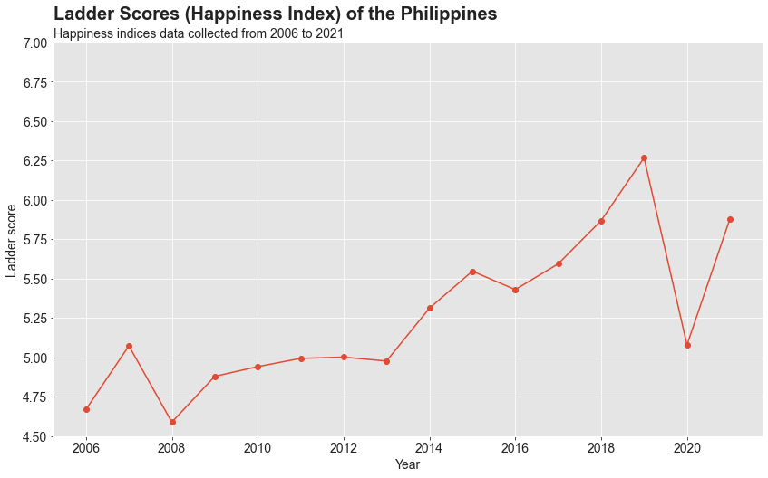

```python
plot_line(df_ph["year"], df_ph["Ladder score"], "Ladder Scores (Happiness Index) of the Philippines", "Happiness indices data collected from 2006 to 2021",
          "Year", "Ladder score", 0.368)
```

### Pearson Correlation (standard correlation coefficient) of features

```python
feature_corr = df_ph[df_ph.columns.difference(["Country", "year"])]

feature_corr.corr()
```

|  | Freedom to make life choices | Generosity | Healthy life expectancy | Ladder score | Log GDP per capita | Perceptions of corruption | Social support |
| --- | --- | --- | --- | --- | --- | --- | --- |
| Freedom to make life choices | 1.000000 | -0.678234 | 0.923263 | 0.618564 | 0.852727 | -0.875319 | 0.530580 |
| Generosity | -0.678234 | 1.000000 | -0.810246 | -0.777069 | -0.863951 | 0.636882 | -0.499561 |
| Healthy life expectancy | 0.923263 | -0.810246 | 1.000000 | 0.796735 | 0.978401 | -0.875596 | 0.587733 |
| Ladder score | 0.618564 | -0.777069 | 0.796735 | 1.000000 | 0.850987 | -0.638507 | 0.709564 |
| Log GDP per capita | 0.852727 | -0.863951 | 0.978401 | 0.850987 | 1.000000 | -0.838708 | 0.595536 |
| Perceptions of corruption | -0.875319 | 0.636882 | -0.875596 | -0.638507 | -0.838708 | 1.000000 | -0.612932 |
| Social support | 0.530580 | -0.499561 | 0.587733 | 0.709564 | 0.595536 | -0.612932 | 1.000000 |

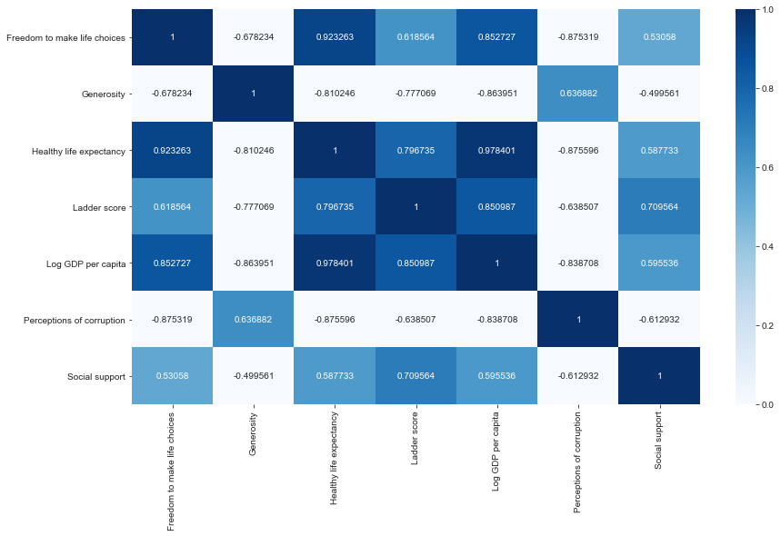

```python
plt.figure(figsize=(14,8))
sns.heatmap(feature_corr.corr(), annot=True, fmt="g", vmin=0, cmap="Blues")
```

### Statistical test for establishing relationship between features

p-value ≤ α: The correlation is statistically significant

If the p-value is less than or equal to the significance level (α = 0.05 or confidence interval = 95%), then one can conclude that the correlation is different from 0.

```python
# (correlation, p-value)

pearsonr(df_ph["Log GDP per capita"], df_ph["Healthy life expectancy"])
```

```
(0.9784012996320547, 5.5539247012691395e-11)
```

```python
pearsonr(df_ph["Freedom to make life choices"], df_ph["Healthy life expectancy"])
```

```
(0.9232631941919032, 3.423774679928049e-07)
```

```python
pearsonr(df_ph["Log GDP per capita"], df_ph["Ladder score"])
```

```
(0.8509873573343982, 2.922413061494319e-05)
```

```python
pearsonr(df_ph["Perceptions of corruption"], df_ph["Healthy life expectancy"])
```

```
(-0.8755964469219779, 8.84474766153686e-06)
```

```python
pearsonr(df_ph["Perceptions of corruption"], df_ph["Freedom to make life choices"])
```

```
(-0.8753191934107426, 8.9767790795422e-06)
```

### Plotting correlation analysis

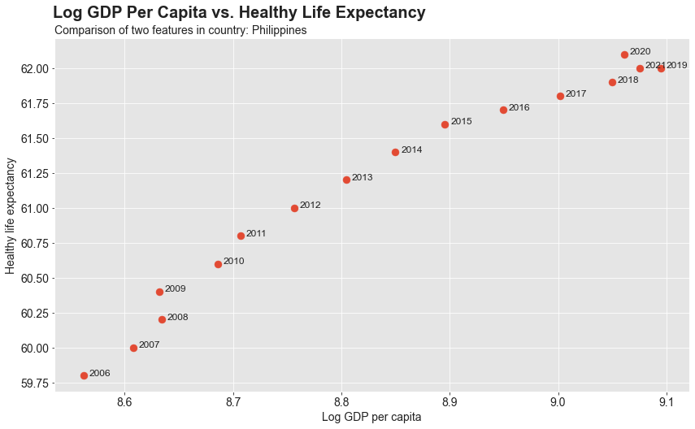

```python
plot_scatter(df_ph["Log GDP per capita"], df_ph["Healthy life expectancy"], df_ph["year"],
             "Log GDP Per Capita vs. Healthy Life Expectancy", "Comparison of two features in country: Philippines",
             "Log GDP per capita", "Healthy life expectancy", 0.351, 0.005)
```

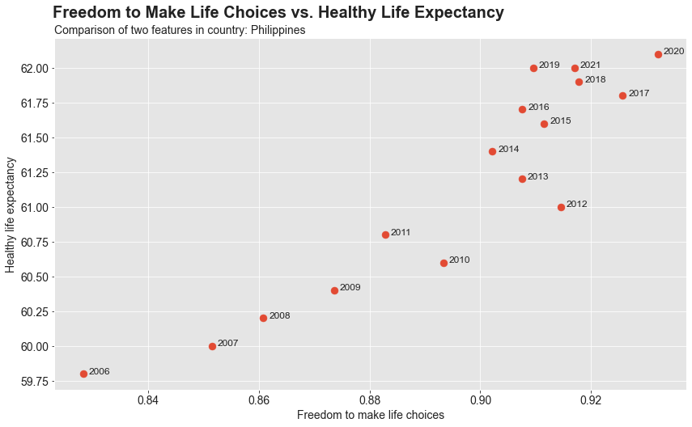

```python
plot_scatter(df_ph["Freedom to make life choices"], df_ph["Healthy life expectancy"], df_ph["year"],
             "Freedom to Make Life Choices vs. Healthy Life Expectancy", "Comparison of two features in country: Philippines",
             "Freedom to make life choices", "Healthy life expectancy", 0.4, 0.001)
```

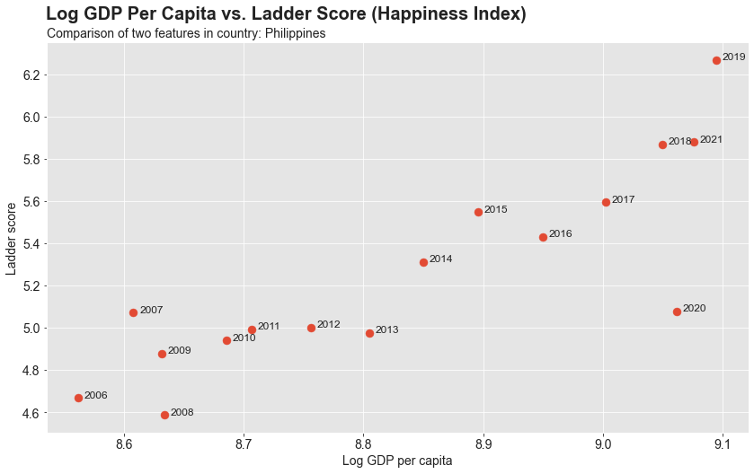

```python
plot_scatter(df_ph["Log GDP per capita"], df_ph["Ladder score"], df_ph["year"],
             "Log GDP Per Capita vs. Ladder Score (Happiness Index)", "Comparison of two features in country: Philippines",
             "Log GDP per capita", "Ladder score", 0.39, 0.005)
```

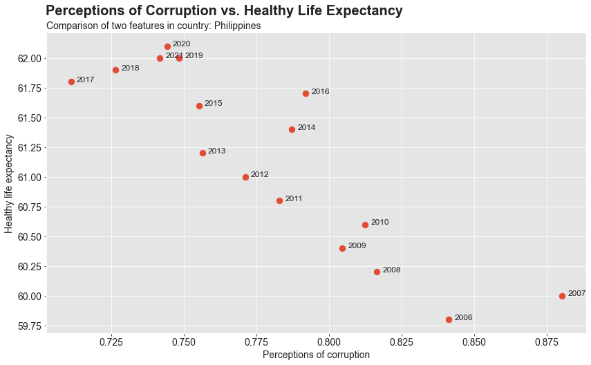

```python
plot_scatter(df_ph["Perceptions of corruption"], df_ph["Healthy life expectancy"], df_ph["year"],
             "Perceptions of Corruption vs. Healthy Life Expectancy", "Comparison of two features in country: Philippines",
             "Perceptions of corruption", "Healthy life expectancy", 0.38, 0.002)
```

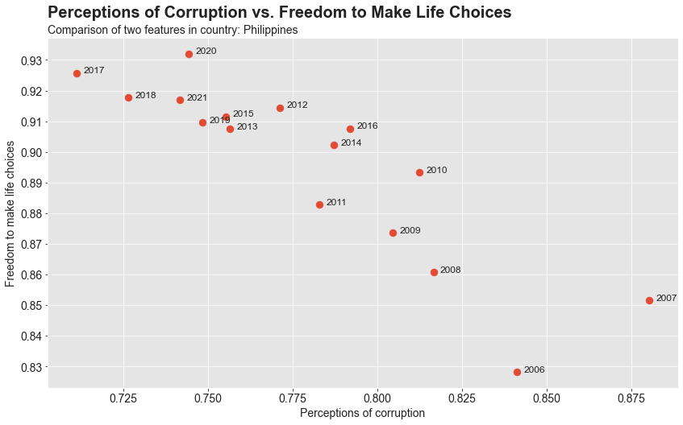

```python
plot_scatter(df_ph["Perceptions of corruption"], df_ph["Freedom to make life choices"], df_ph["year"],
             "Perceptions of Corruption vs. Freedom to Make Life Choices", "Comparison of two features in country: Philippines",
             "Perceptions of corruption", "Freedom to make life choices", 0.41, 0.002)
```

# Philippines vs. ASEAN Countries

### 2006-2021 Dataset

```python
sea_countries = ["Philippines", "Singapore", "Vietnam", "Indonesia", "Thailand", "Cambodia", "Laos", "Malaysia", "Myanmar"]
```

```python
df_sea_all = pd.DataFrame([], columns=["Country", "Ladder score"])

for country in sea_countries:
    df_sea_all = pd.concat([df_sea_all,
                             df_groupby_country_sorted[df_groupby_country_sorted["Country"] == country][["Country", "Ladder score"]]])


df_sea_all.sort_values(by="Ladder score", ascending=False)
```

|  | Country | Ladder score |
| --- | --- | --- |
| 29 | Singapore | 6.495141 |
| 45 | Thailand | 6.080983 |
| 58 | Malaysia | 5.763796 |
| 83 | Vietnam | 5.312868 |
| 85 | Philippines | 5.256793 |
| 87 | Indonesia | 5.235466 |
| 100 | Laos | 5.005780 |
| 133 | Myanmar | 4.410420 |
| 142 | Cambodia | 4.287066 |

### 2021 Dataset

```python
df_2021_sorted = df2.sort_values(by="Ladder score", ascending=False, ignore_index=True)

df_sea_2021 = pd.DataFrame([], columns=["Country", "Ladder score"])

for country in sea_countries:
    df_sea_2021 = pd.concat([df_sea_2021,
                             df_2021_sorted[df_2021_sorted["Country"] == country][["Country", "Ladder score"]]])


df_sea_2021.sort_values(by="Ladder score", ascending=False)
```

|  | Country | Ladder score |
| --- | --- | --- |
| 31 | Singapore | 6.3765 |
| 53 | Thailand | 5.9847 |
| 60 | Philippines | 5.8802 |
| 78 | Vietnam | 5.4108 |
| 80 | Malaysia | 5.3843 |
| 81 | Indonesia | 5.3445 |
| 99 | Laos | 5.0300 |
| 113 | Cambodia | 4.8304 |
| 125 | Myanmar | 4.4258 |

### Randomly sampling four (4) ASEAN countries + Philippines

```python
countries = ["Singapore", "Vietnam", "Indonesia", "Thailand", "Cambodia", "Laos", "Malaysia", "Myanmar"]

np.random.seed(30)
sampled_countries = np.random.choice(countries, 4, replace=False)

sampled_countries
```

```
array(['Thailand', 'Vietnam', 'Indonesia', 'Singapore'], dtype='<U9')
```

```python
sampled_countries = np.append("Philippines", sampled_countries)

sampled_countries.tolist()
```

```
['Philippines', 'Thailand', 'Vietnam', 'Indonesia', 'Singapore']
```

```python
# Philippines data in year 2021

df_ph_2021 = df_ph[df_ph["year"] == 2021]

df_ph_2021
```

|  | Country | year | Ladder score | Log GDP per capita | Social support | Healthy life expectancy | Freedom to make life choices | Generosity | Perceptions of corruption |
| --- | --- | --- | --- | --- | --- | --- | --- | --- | --- |
| 2009 | Philippines | 2021 | 5.8802 | 9.075588 | 0.829926 | 61.999954 | 0.916999 | -0.096836 | 0.741764 |

### Comparison of ladder scores of selected ASEAN countries

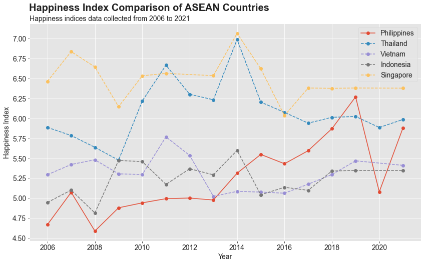

```python
plt.figure(figsize=(14,8))

for country in sampled_countries:
    x = df[df["Country"] == country]["year"]
    y = df[df["Country"] == country]["Ladder score"]

    if country != "Philippines":
        plt.plot(x, y, marker="o", linestyle="--", label=country)
    else:
        plt.plot(x, y, marker="o", label=country)


plt.legend(fontsize=14)
plt.locator_params(axis="y", nbins=12)
plt.suptitle("Happiness Index Comparison of ASEAN Countries", x=0.362, y=0.95, fontsize=20, fontweight="bold")
plt.title("Happiness indices data collected from 2006 to 2021", loc="left", fontsize=14)

plt.xticks(fontsize=14); plt.yticks(fontsize=14)
plt.xlabel("Year", fontsize=14); plt.ylabel("Happiness Index", fontsize=14)
#plt.gca().xaxis.grid(False)
```

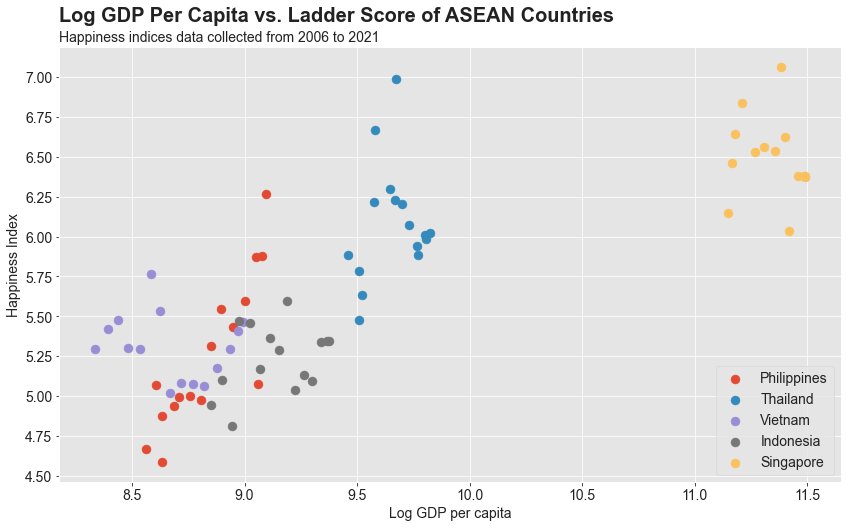

```python
plt.figure(figsize=(14,8))

for country in sampled_countries:
    x = df[df["Country"] == country]["Log GDP per capita"]
    y = df[df["Country"] == country]["Ladder score"]

    plt.scatter(x, y, marker="o", s=80, label=country)


plt.legend(fontsize=14, loc=4)
plt.locator_params(axis="y", nbins=12)
plt.suptitle("Log GDP Per Capita vs. Ladder Score of ASEAN Countries", x=0.4, y=0.95, fontsize=20, fontweight="bold")
plt.title("Happiness indices data collected from 2006 to 2021", loc="left", fontsize=14)

plt.xticks(fontsize=14); plt.yticks(fontsize=14)
plt.xlabel("Log GDP per capita", fontsize=14); plt.ylabel("Happiness Index", fontsize=14)
#plt.gca().xaxis.grid(False)
```

### Comparison of ladder scores of all ASEAN countries

```python
df_sea = df[(df["year"] == 2021) & ((df["Country"] == "Philippines") | (df["Country"] == "Singapore") | (df["Country"] == "Vietnam") | (df["Country"] == "Indonesia") |
            (df["Country"] == "Thailand") | (df["Country"] == "Cambodia") | (df["Country"] == "Laos") | (df["Country"] == "Malaysia") | (df["Country"] == "Myanmar"))]

df_sea
```

|  | Country | year | Ladder score | Log GDP per capita | Social support | Healthy life expectancy | Freedom to make life choices | Generosity | Perceptions of corruption |
| --- | --- | --- | --- | --- | --- | --- | --- | --- | --- |
| 1980 | Singapore | 2021 | 6.3765 | 11.488009 | 0.914899 | 76.952858 | 0.927198 | -0.018427 | 0.081959 |
| 2002 | Thailand | 2021 | 5.9847 | 9.804680 | 0.887529 | 67.401100 | 0.884038 | 0.287391 | 0.895368 |
| 2009 | Philippines | 2021 | 5.8802 | 9.075588 | 0.829926 | 61.999954 | 0.916999 | -0.096836 | 0.741764 |
| 2027 | Vietnam | 2021 | 5.4108 | 8.973157 | 0.849987 | 68.034134 | 0.939593 | -0.097614 | 0.796421 |
| 2029 | Malaysia | 2021 | 5.3843 | 10.238157 | 0.816509 | 67.102158 | 0.894627 | 0.125296 | 0.839302 |
| 2030 | Indonesia | 2021 | 5.3445 | 9.364791 | 0.811411 | 62.236362 | 0.872877 | 0.541553 | 0.867314 |
| 2048 | Laos | 2021 | 5.0300 | 8.947352 | 0.727973 | 58.968136 | 0.910053 | 0.123145 | 0.658196 |
| 2062 | Cambodia | 2021 | 4.8304 | 8.360371 | 0.764582 | 62.000336 | 0.958579 | 0.033953 | 0.843456 |
| 2074 | Myanmar | 2021 | 4.4258 | 8.540956 | 0.778949 | 59.301888 | 0.875627 | 0.508871 | 0.659536 |

```python
df_sea.describe()
```

|  | year | Ladder score | Log GDP per capita | Social support | Healthy life expectancy | Freedom to make life choices | Generosity | Perceptions of corruption |
| --- | --- | --- | --- | --- | --- | --- | --- | --- |
| count | 9.0 | 9.000000 | 9.000000 | 9.000000 | 9.000000 | 9.000000 | 9.000000 | 9.000000 |
| mean | 2021.0 | 5.407467 | 9.421451 | 0.820196 | 64.888547 | 0.908843 | 0.156370 | 0.709257 |
| std | 0.0 | 0.606153 | 0.970455 | 0.059028 | 5.663890 | 0.029661 | 0.241356 | 0.250444 |
| min | 2021.0 | 4.425800 | 8.360371 | 0.727973 | 58.968136 | 0.872877 | -0.097614 | 0.081959 |
| 25% | 2021.0 | 5.030000 | 8.947352 | 0.778949 | 61.999954 | 0.884038 | -0.018427 | 0.659536 |
| 50% | 2021.0 | 5.384300 | 9.075588 | 0.816509 | 62.236362 | 0.910053 | 0.123145 | 0.796421 |
| 75% | 2021.0 | 5.880200 | 9.804680 | 0.849987 | 67.401100 | 0.927198 | 0.287391 | 0.843456 |
| max | 2021.0 | 6.376500 | 11.488009 | 0.914899 | 76.952858 | 0.958579 | 0.541553 | 0.895368 |

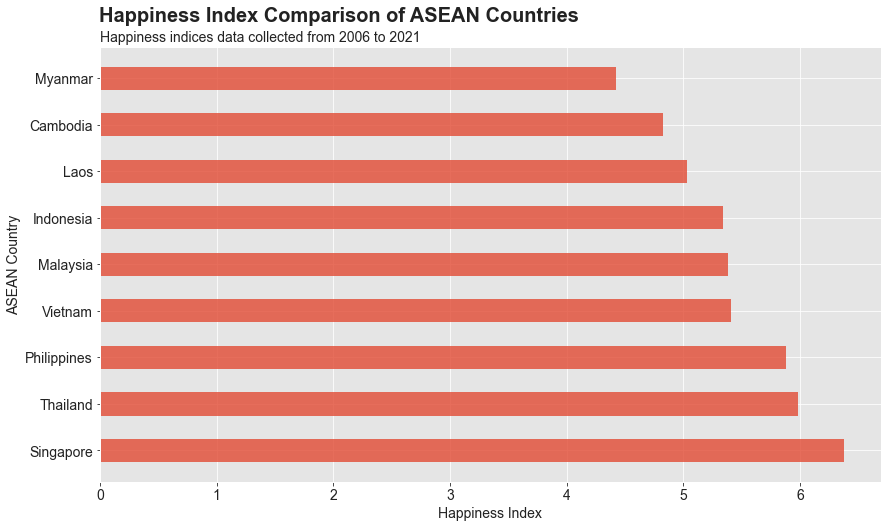

```python
plt.figure(figsize=(14,8))

plt.barh(df_sea["Country"], df_sea["Ladder score"], alpha=0.8, height=0.5)

plt.suptitle("Happiness Index Comparison of ASEAN Countries", x=0.362, y=0.95, fontsize=20, fontweight="bold")
plt.title("Happiness indices data collected from 2006 to 2021", loc="left", fontsize=14)

plt.xticks(fontsize=14); plt.yticks(fontsize=14)
plt.xlabel("Happiness Index", fontsize=14); plt.ylabel("ASEAN Country", fontsize=14)
```

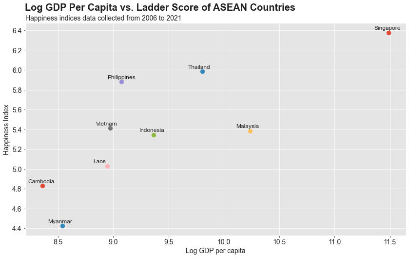

```python
plt.figure(figsize=(14,8))

for x, y, c in zip(df_sea["Log GDP per capita"], df_sea["Ladder score"], df_sea["Country"]):
    plt.scatter(x, y, marker="o", s=80, label=c)
    plt.text(x-0.13, y+0.03, c, fontsize=12)


plt.locator_params(axis="y", nbins=12)
plt.suptitle("Log GDP Per Capita vs. Ladder Score of ASEAN Countries", x=0.4, y=0.95, fontsize=20, fontweight="bold")
plt.title("Happiness indices data collected from 2006 to 2021", loc="left", fontsize=14)

plt.xticks(fontsize=14); plt.yticks(fontsize=14)
plt.xlabel("Log GDP per capita", fontsize=14); plt.ylabel("Happiness Index", fontsize=14)
```

# 2021 Philippines vs. The World

```python
# Descriptive statistics of 2005-2021 dataset

df.describe()
```

|  | year | Ladder score | Log GDP per capita | Social support | Healthy life expectancy | Freedom to make life choices | Generosity | Perceptions of corruption |
| --- | --- | --- | --- | --- | --- | --- | --- | --- |
| count | 2098.000000 | 2098.000000 | 2098.000000 | 2098.000000 | 2098.000000 | 2098.000000 | 2098.000000 | 2098.000000 |
| mean | 2013.768827 | 5.471403 | 9.378010 | 0.813161 | 63.439433 | 0.746260 | -0.001448 | 0.740181 |
| std | 4.486449 | 1.112682 | 1.153046 | 0.118080 | 7.451472 | 0.141071 | 0.160730 | 0.188215 |
| min | 2005.000000 | 2.375092 | 6.635322 | 0.290184 | 32.299999 | 0.257534 | -0.335040 | 0.035198 |
| 25% | 2010.000000 | 4.652504 | 8.480264 | 0.750301 | 58.804999 | 0.651839 | -0.114605 | 0.681997 |
| 50% | 2014.000000 | 5.391887 | 9.464589 | 0.835835 | 65.199997 | 0.768215 | -0.028290 | 0.797906 |
| 75% | 2018.000000 | 6.282982 | 10.371108 | 0.905294 | 68.615086 | 0.859330 | 0.089273 | 0.866382 |
| max | 2021.000000 | 8.018934 | 11.648169 | 0.987343 | 77.099998 | 0.985178 | 0.698099 | 0.983276 |

```python
df_2021_sorted
```

|  | Country | Ladder score | Log GDP per capita | Social support | Healthy life expectancy | Freedom to make life choices | Generosity | Perceptions of corruption |
| --- | --- | --- | --- | --- | --- | --- | --- | --- |
| 0 | Finland | 7.8421 | 10.775202 | 0.953603 | 72.000000 | 0.949268 | -0.097760 | 0.185846 |
| 1 | Denmark | 7.6195 | 10.933176 | 0.954410 | 72.699753 | 0.945639 | 0.030109 | 0.178838 |
| 2 | Switzerland | 7.5715 | 11.117368 | 0.941742 | 74.400101 | 0.918788 | 0.024629 | 0.291698 |
| 3 | Iceland | 7.5539 | 10.877768 | 0.982938 | 73.000000 | 0.955123 | 0.160274 | 0.672865 |
| 4 | Netherlands | 7.4640 | 10.931812 | 0.941601 | 72.400116 | 0.913116 | 0.175404 | 0.337938 |
| ... | ... | ... | ... | ... | ... | ... | ... | ... |
| 144 | Lesotho | 3.5118 | 7.925777 | 0.786871 | 48.700001 | 0.714954 | -0.130536 | 0.915377 |
| 145 | Botswana | 3.4665 | 9.781536 | 0.784171 | 59.269188 | 0.824394 | -0.246159 | 0.800619 |
| 146 | Rwanda | 3.4147 | 7.676118 | 0.552339 | 61.399727 | 0.896758 | 0.060526 | 0.166801 |
| 147 | Zimbabwe | 3.1448 | 7.942595 | 0.750470 | 56.200840 | 0.676700 | -0.047346 | 0.820999 |
| 148 | Afghanistan | 2.5229 | 7.694710 | 0.462596 | 52.492615 | 0.381749 | -0.101684 | 0.924338 |

149 rows × 8 columns

```python
df_2021_sorted[df_2021_sorted["Country"] == "Philippines"]
```

|  | Country | Ladder score | Log GDP per capita | Social support | Healthy life expectancy | Freedom to make life choices | Generosity | Perceptions of corruption |
| --- | --- | --- | --- | --- | --- | --- | --- | --- |
| 60 | Philippines | 5.8802 | 9.075588 | 0.829926 | 61.999954 | 0.916999 | -0.096836 | 0.741764 |

```python
df_2021 = df[df["year"] == 2021]


df_2021_sampled = df_2021.sample(19, random_state=42)

df_2021_sampled
```

|  | Country | year | Ladder score | Log GDP per capita | Social support | Healthy life expectancy | Freedom to make life choices | Generosity | Perceptions of corruption |
| --- | --- | --- | --- | --- | --- | --- | --- | --- | --- |
| 2022 | North Cyprus | 2021 | 5.5355 | 10.576036 | 0.820357 | 73.897537 | 0.795294 | 0.012134 | 0.626116 |
| 1967 | United States | 2021 | 6.9515 | 11.023136 | 0.919849 | 68.199860 | 0.836963 | 0.098437 | 0.698064 |
| 2066 | Iran | 2021 | 4.7212 | 9.584374 | 0.710052 | 66.300354 | 0.607501 | 0.218477 | 0.714196 |
| 2027 | Vietnam | 2021 | 5.4108 | 8.973157 | 0.849987 | 68.034134 | 0.939593 | -0.097614 | 0.796421 |
| 2025 | Hong Kong S.A.R. of China | 2021 | 5.4767 | 11.000313 | 0.835781 | 76.820091 | 0.716808 | 0.067344 | 0.402650 |
| 1980 | Singapore | 2021 | 6.3765 | 11.488009 | 0.914899 | 76.952858 | 0.927198 | -0.018427 | 0.081959 |
| 2013 | Moldova | 2021 | 5.7664 | 9.453942 | 0.856775 | 65.698593 | 0.822087 | -0.078677 | 0.918214 |
| 2089 | Yemen | 2021 | 3.6579 | 7.578437 | 0.831537 | 57.121571 | 0.602157 | -0.146712 | 0.800288 |
| 2017 | Bolivia | 2021 | 5.7159 | 9.045671 | 0.809597 | 63.901218 | 0.874642 | -0.077319 | 0.839006 |
| 2031 | Congo (Brazzaville) | 2021 | 5.3417 | 8.117217 | 0.636479 | 58.220947 | 0.694734 | -0.067540 | 0.744673 |
| 2058 | Ukraine | 2021 | 4.8748 | 9.436073 | 0.887920 | 64.901749 | 0.724447 | -0.011033 | 0.923817 |
| 1961 | Germany | 2021 | 7.1545 | 10.872547 | 0.903166 | 72.500099 | 0.875170 | 0.010640 | 0.460145 |
| 1985 | Jamaica | 2021 | 6.3092 | 9.186201 | 0.876502 | 67.500000 | 0.889583 | -0.136797 | 0.884409 |
| 1958 | Austria | 2021 | 7.2678 | 10.906316 | 0.934176 | 73.299721 | 0.907691 | 0.041568 | 0.481378 |
| 1968 | Belgium | 2021 | 6.8340 | 10.823075 | 0.905531 | 72.199425 | 0.783322 | -0.153368 | 0.645584 |
| 2005 | Argentina | 2021 | 5.9293 | 9.961632 | 0.897524 | 69.000153 | 0.828486 | -0.181704 | 0.833957 |
| 2085 | Zambia | 2021 | 4.0734 | 8.145451 | 0.707518 | 55.809212 | 0.781900 | 0.060521 | 0.823431 |
| 2018 | Mongolia | 2021 | 5.6772 | 9.400178 | 0.935173 | 62.500114 | 0.707625 | 0.115514 | 0.856477 |
| 2004 | Japan | 2021 | 5.9405 | 10.611434 | 0.883942 | 75.100441 | 0.795744 | -0.258194 | 0.637886 |

```python
# Sort countries by Ladder score

df_2021[["Country", "Ladder score", "Log GDP per capita"]].sort_values(by="Ladder score", ascending=False)
```

|  | Country | Ladder score | Log GDP per capita |
| --- | --- | --- | --- |
| 1949 | Finland | 7.8421 | 10.775202 |
| 1950 | Denmark | 7.6195 | 10.933176 |
| 1951 | Switzerland | 7.5715 | 11.117368 |
| 1952 | Iceland | 7.5539 | 10.877768 |
| 1953 | Netherlands | 7.4640 | 10.931812 |
| ... | ... | ... | ... |
| 2093 | Lesotho | 3.5118 | 7.925777 |
| 2094 | Botswana | 3.4665 | 9.781536 |
| 2095 | Rwanda | 3.4147 | 7.676118 |
| 2096 | Zimbabwe | 3.1448 | 7.942595 |
| 2097 | Afghanistan | 2.5229 | 7.694710 |

149 rows × 3 columns

```python
# Sort countries by Log GDP per capita

df_2021[["Country", "Ladder score", "Log GDP per capita"]].sort_values(by="Log GDP per capita", ascending=False)
```

|  | Country | Ladder score | Log GDP per capita |
| --- | --- | --- | --- |
| 1956 | Luxembourg | 7.3244 | 11.646564 |
| 1980 | Singapore | 6.3765 | 11.488009 |
| 1963 | Ireland | 7.0853 | 11.342286 |
| 1951 | Switzerland | 7.5715 | 11.117368 |
| 1973 | United Arab Emirates | 6.5605 | 11.084889 |
| ... | ... | ... | ... |
| 2068 | Liberia | 4.6252 | 7.287706 |
| 2063 | Mozambique | 4.7945 | 7.158463 |
| 2044 | Niger | 5.0741 | 7.097615 |
| 2092 | Malawi | 3.6000 | 6.957525 |
| 2088 | Burundi | 3.7753 | 6.635322 |

149 rows × 3 columns

[output not shown]

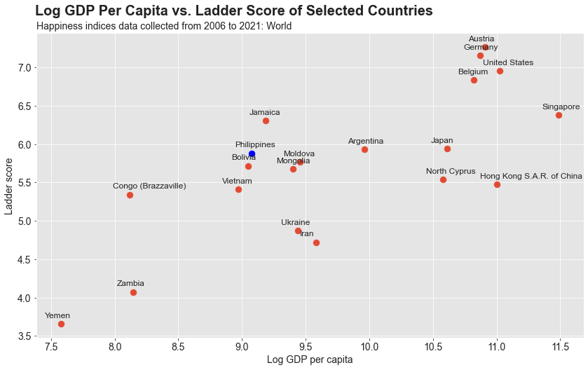

```python
plt.figure(figsize=(14,8))

plt.scatter(df_2021_sampled["Log GDP per capita"], df_2021_sampled["Ladder score"], s=80)
plt.scatter(df_ph_2021["Log GDP per capita"], df_ph_2021["Ladder score"], s=80, color="blue")

plt.locator_params(axis="y", nbins=12)
plt.suptitle("Log GDP Per Capita vs. Ladder Score of Selected Countries", x=0.405, y=0.95, fontsize=20, fontweight="bold")
plt.title("Happiness indices data collected from 2006 to 2021: World", loc="left", fontsize=14)

plt.xticks(fontsize=14); plt.yticks(fontsize=14)
plt.xlabel("Log GDP per capita", fontsize=14); plt.ylabel("Ladder score", fontsize=14)

for x,y,country in zip (df_2021_sampled["Log GDP per capita"], df_2021_sampled["Ladder score"], df_2021_sampled["Country"]):
    plt.text(x-0.13, y+0.08, country, fontsize=12)

plt.text(df_ph_2021["Log GDP per capita"]-0.13, df_ph_2021["Ladder score"]+0.08, "Philippines", fontsize=12)
```

# Conclusion

### State of the happiness score of the Philippines in the world

In the ASEAN Region, the Philippines ranked 3rd happiest country with 5.8802 ladder score in 2021. In historical data, the Philippines ranked 5th happiest country with 5.256793 ladder score. See "Philippines vs. ASEAN Countries" section for more information.

### Factors that highly affect the happiness score of the Philippines

The factors affecting the happiness score of the Philippines are determined using standard correlation coefficient or Pearson's correlation. The correlation table is graphed in a heatmap to identify the spots where high positive and negative relationships are found.

On positive relationship, the log GDP per capita and healthy life expectancy at birth scores the highest positive correlation at 0.978401. This means that the two features move in the same positive direction. If the log GDP per capita increases, healthy life expectancy at birth also increases. The correlation between the two features is statistically significant at confidence level of 95% (α of 0.05 > p-value of 5.5539247012691395e-11).

Next is the freedom to make life choices and healthy life expectancy at 0.923263 (α of 0.05 > p-value of 3.423774679928049e-07). Lastly, the log GDP per capita and ladder score at 0.850987 (α of 0.05 > p-value of 2.922413061494319e-05). All are statistically significant.

On negative relationship, the perceptions of corruption and healthy life expectancy scores at -0.875596. This means that the two features move in the same negative direction. If the perceptions of corruption increases, healthy life expectancy at birth healthy life expectancy decreases. The correlation between the two features is statistically significant at confidence level of 95% (α of 0.05 > p-value of 8.84474766153686e-06). Next is the perceptions of corruption and freedom to make life choices at -0.875319 (α of 0.05 > p-value of 8.9767790795422e-06), also statistically significant.

### Other Observations

- In 2021, Finland topped the rankings as the happiest country in the world with a ladder score of 7.8421.
- In analyzing historical data, Denmark led the rankings with 7.676504 mean ladder score from 2005-2021.
- Luxembourg has the highest Log GDP per capita at 11.646564 and managed to be at 8th spot in the world at 7.3244 ladder score in 2021.
- In both 2021 and historical data, all countries included in the top 10 highest ladder scores have Log GDP per capita ranging from 10 to 11, higher healthy life expectancy at birth ranging from 71 and above, freedom to make life choices and social support ranging from 0.90 and above.
- Norway has the highest freedom to make life choices at 0.954847 score and managed to be included in top countries sorted by ladder score in historical data (ranked 4th).
- In ASEAN Region, Singapore topped both 2021 and historical datasets at 6.3765 and 6.495141 ladder scores, respectively.
- All ASEAN countries, except Brunei, are present in both datasets.
- Note: Since DataFrame indices start at 0, all rankings from the datasets are adjusted (n+1) to fit the real-world scenario of ranking countries.

```python
df_2021_sorted.head(11)
```

|  | Country | Ladder score | Log GDP per capita | Social support | Healthy life expectancy | Freedom to make life choices | Generosity | Perceptions of corruption |
| --- | --- | --- | --- | --- | --- | --- | --- | --- |
| 0 | Finland | 7.8421 | 10.775202 | 0.953603 | 72.000000 | 0.949268 | -0.097760 | 0.185846 |
| 1 | Denmark | 7.6195 | 10.933176 | 0.954410 | 72.699753 | 0.945639 | 0.030109 | 0.178838 |
| 2 | Switzerland | 7.5715 | 11.117368 | 0.941742 | 74.400101 | 0.918788 | 0.024629 | 0.291698 |
| 3 | Iceland | 7.5539 | 10.877768 | 0.982938 | 73.000000 | 0.955123 | 0.160274 | 0.672865 |
| 4 | Netherlands | 7.4640 | 10.931812 | 0.941601 | 72.400116 | 0.913116 | 0.175404 | 0.337938 |
| 5 | Norway | 7.3925 | 11.053126 | 0.954445 | 73.300011 | 0.959588 | 0.093426 | 0.270028 |
| 6 | Sweden | 7.3627 | 10.866995 | 0.933805 | 72.700050 | 0.944604 | 0.086223 | 0.237460 |
| 7 | Luxembourg | 7.3244 | 11.646564 | 0.907790 | 72.599998 | 0.907180 | -0.033566 | 0.386419 |
| 8 | New Zealand | 7.2766 | 10.642713 | 0.948148 | 73.400146 | 0.928580 | 0.134256 | 0.241641 |
| 9 | Austria | 7.2678 | 10.906316 | 0.934176 | 73.299721 | 0.907691 | 0.041568 | 0.481378 |
| 10 | Australia | 7.1835 | 10.795605 | 0.940149 | 73.900093 | 0.913650 | 0.158530 | 0.442292 |

```python
df_groupby_country_sorted.head(11)
```

|  | Country | year | Ladder score | Log GDP per capita | Social support | Healthy life expectancy | Freedom to make life choices | Generosity | Perceptions of corruption |
| --- | --- | --- | --- | --- | --- | --- | --- | --- | --- |
| 0 | Denmark | 2013.437500 | 7.676504 | 10.882655 | 0.957034 | 71.264984 | 0.945163 | 0.143516 | 0.199057 |
| 1 | Finland | 2014.285714 | 7.614708 | 10.751747 | 0.949302 | 71.238572 | 0.940386 | -0.004024 | 0.244426 |
| 2 | Switzerland | 2015.181818 | 7.550344 | 11.097398 | 0.943440 | 73.430918 | 0.924320 | 0.099061 | 0.304636 |
| 3 | Norway | 2015.090909 | 7.501651 | 11.040443 | 0.950735 | 72.727273 | 0.954847 | 0.132170 | 0.337352 |
| 4 | Netherlands | 2013.733333 | 7.466140 | 10.889793 | 0.934058 | 71.753341 | 0.907887 | 0.262452 | 0.409758 |
| 5 | Iceland | 2015.666667 | 7.458506 | 10.862636 | 0.978174 | 72.880000 | 0.934128 | 0.245856 | 0.697742 |
| 6 | Sweden | 2013.437500 | 7.369100 | 10.822570 | 0.928215 | 72.147504 | 0.930504 | 0.123043 | 0.290014 |
| 7 | Canada | 2013.437500 | 7.359256 | 10.749999 | 0.936518 | 72.763737 | 0.927168 | 0.209759 | 0.417555 |
| 8 | New Zealand | 2013.800000 | 7.308057 | 10.587097 | 0.952560 | 72.493343 | 0.923490 | 0.248278 | 0.264512 |
| 9 | Australia | 2013.733333 | 7.275456 | 10.758180 | 0.946779 | 72.773339 | 0.921115 | 0.236701 | 0.417214 |
| 10 | Austria | 2014.285714 | 7.244053 | 10.888340 | 0.929927 | 72.188552 | 0.906303 | 0.124092 | 0.563846 |

### Recommendations

- Due to limited time, some important uncovered variables are not examined by this analysis (eg. countries that are highest in terms of other features not mentioned above or not covered in the EDA).
- Since the analyst is still learning, improvement in coding structure, data analysis, interpretation, and documentation are matters needed to enhance.
- Future notebook can be split into multiple notebooks for organization and readability purposes (eg. one for data pre-processing and another one for the EDA).
- For future analysis, it is much better to include individual raw datasets of each year when analyzing historical data.

### References

Helliwell, J., Huang H., Wang S., & Norton, M. (2021). Statistical Appendix 1 for Chapter 2 of World Happiness Report 2021. https://happiness-report.s3.amazonaws.com/2021/Appendix1WHR2021C2.pdf

Helliwell, J., Layard, R., Sachs, J., De Neve, J.E., Aknin, L., Wang S. (2021). World Happiness Report 2021. World Happiness Report. https://happiness-report.s3.amazonaws.com/2021/WHR+21.pdf

Minitab Express™ Support. (n.d.). *Interpret the key results for Correlation*. Retrieved March 12, 2022, from https://support.minitab.com/en-us/minitab-express/1/help-and-how-to/modeling-statistics/regression/how-to/correlation/interpret-the-results/

World Happiness Report. (n.d.). *Home | The World Happiness Report*. Retrieved March 12, 2022, from https://worldhappiness.report/